# matplotlib.axes.Axes.set_yscale

**Axes.set_yscale(*value*, **kwargs)[[source]](https://github.com/matplotlib/matplotlib/blob/v3.9.2/lib/matplotlib/axes/_base.py#L73-L74)**

Set the yaxis' scale.

**Parameters:**

**value**{"linear", "log", "symlog", "logit", ...} or `ScaleBase`**

The axis scale type to apply.

**kwargs**

Different keyword arguments are accepted, depending on the scale. See the respective class keyword arguments:

- `matplotlib.scale.LinearScale`
- `matplotlib.scale.LogScale`
- `matplotlib.scale.SymmetricalLogScale`
- `matplotlib.scale.LogitScale`
- `matplotlib.scale.FuncScale`
- `matplotlib.scale.AsinhScale`

#### Notes

By default, Matplotlib supports the above-mentioned scales. Additionally, custom scales may be registered using `matplotlib.scale.register_scale`. These scales can then also be used here.

## Examples using `matplotlib.axes.Axes.set_yscale`

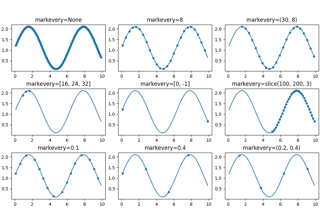

[Markevery Demo](https://matplotlib.org/stable/gallery/lines_bars_and_markers/markevery_demo.html#sphx-glr-gallery-lines-bars-and-markers-markevery-demo-py)

Markevery Demo

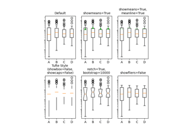

[Artist customization in box plots](https://matplotlib.org/stable/gallery/statistics/boxplot.html#sphx-glr-gallery-statistics-boxplot-py)

Artist customization in box plots

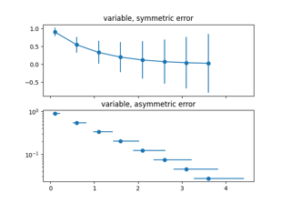

[Different ways of specifying error bars](https://matplotlib.org/stable/gallery/statistics/errorbar_features.html#sphx-glr-gallery-statistics-errorbar-features-py)

Different ways of specifying error bars

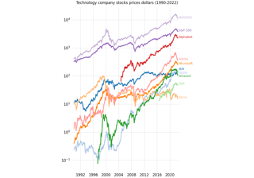

[Stock prices over 32 years](https://matplotlib.org/stable/gallery/showcase/stock_prices.html#sphx-glr-gallery-showcase-stock-prices-py)

Stock prices over 32 years

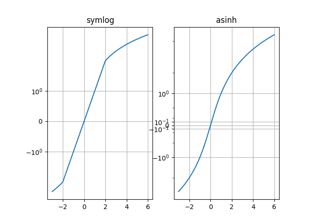

[Asinh Demo](https://matplotlib.org/stable/gallery/scales/asinh_demo.html#sphx-glr-gallery-scales-asinh-demo-py)

Asinh Demo

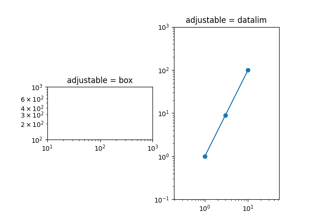

[Loglog Aspect](https://matplotlib.org/stable/gallery/scales/aspect_loglog.html#sphx-glr-gallery-scales-aspect-loglog-py)

Loglog Aspect

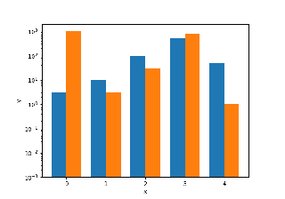

[Log Bar](https://matplotlib.org/stable/gallery/scales/log_bar.html#sphx-glr-gallery-scales-log-bar-py)

Log Bar

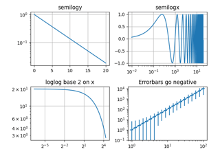

[Log Demo](https://matplotlib.org/stable/gallery/scales/log_demo.html#sphx-glr-gallery-scales-log-demo-py)

Log Demo

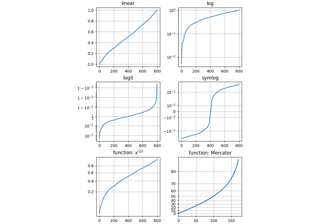

[Scales](https://matplotlib.org/stable/gallery/scales/scales.html#sphx-glr-gallery-scales-scales-py)

Scales

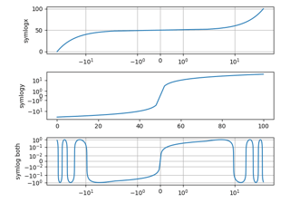

[Symlog Demo](https://matplotlib.org/stable/gallery/scales/symlog_demo.html#sphx-glr-gallery-scales-symlog-demo-py)

Symlog Demo

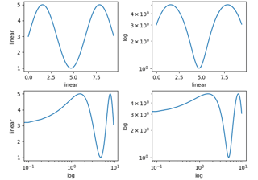

[Axis scales](https://matplotlib.org/stable/users/explain/axes/axes_scales.html#sphx-glr-users-explain-axes-axes-scales-py)

Axis scales

© 2012–2023 Matplotlib Development Team. All rights reserved.  
Licensed under the Matplotlib License Agreement.  
https://matplotlib.org/stable/api/_as_gen/matplotlib.axes.Axes.set_yscale.html